```python
import pandas as pd
import numpy as np
import matplotlib.pyplot as plt
import seaborn as sns

import warnings
warnings.filterwarnings("ignore")

import statsmodels.api as sm
from statsmodels.tsa.stattools import adfuller, acf, pacf
from statsmodels.graphics.tsaplots import plot_acf, plot_pacf
from statsmodels.tsa.seasonal import seasonal_decompose

from sklearn import metrics
from pmdarima import auto_arima
```

# 1. Data Loading

```python
# Load the Netflix stock data from the CSV file
# Set the first column (likely the Date) as the index
df = pd.read_csv('NFLX.csv',  index_col=0)

# Remove unnecessary columns, keeping only the 'High' column for further analysis
df.drop(columns = ['Open', 'Low', 'Close', 'Adj Close', 'Volume'],inplace=True)
```

- Convert index to datetime
- Set daily frequency
- Sort data by date

```python
# Convert index to datetime format for time series operations
df.index = pd.to_datetime(df.index)
```

```python
# Since the data is daily, set the frequency to "D" (Daily)
df.index.asfreq = 'D'

# Sort the DataFrame by date in ascending order
df = df.sort_index()
```

# 2. Data Checking

```python
# Display the first 5 rows to preview the beginning of the dataset
df.head(5)
```

| Date | High |
| --- | --- |
| 2018-02-05 | 267.90 |
| 2018-02-06 | 266.70 |
| 2018-02-07 | 272.45 |
| 2018-02-08 | 267.62 |
| 2018-02-09 | 255.80 |

```python
# Display the last 5 rows to verify the dataset’s end
df.tail(5)
```

| Date | High |
| --- | --- |
| 2022-01-31 | 427.70 |
| 2022-02-01 | 458.48 |
| 2022-02-02 | 451.98 |
| 2022-02-03 | 429.26 |
| 2022-02-04 | 412.77 |

```python
df.info()
```

```
<class 'pandas.core.frame.DataFrame'>
DatetimeIndex: 1009 entries, 2018-02-05 to 2022-02-04
Data columns (total 1 columns):
 #   Column  Non-Null Count  Dtype
---  ------  --------------  -----
 0   High    1009 non-null   float64
dtypes: float64(1)
memory usage: 15.8 KB
```

```python
df.isnull().sum()
```

```
High    0
dtype: int64
```

Kiểm tra xem ngày có bị thiếu hay không?

```python
# Create a complete daily date range from the first to the last date
full_dates = pd.date_range(start=df.index.min(), end=df.index.max(), freq='D')

# Identify missing dates that are not in the current index
missing_dates = full_dates.difference(df.index)

# Print the number of missing days
print('Số ngày bị thiếu:',len(missing_dates))
```

```
Số ngày bị thiếu: 452
```

Thêm dữ liệu vào ngày bị thiếu, áp dụng phương pháp interpolate

```python
# Create a new DataFrame with all dates as index
full_df = pd.DataFrame(index=full_dates)

# Assign 'High' column values from the original dataset
full_df['High'] = df['High']

# Fill missing values using linear interpolation
full_df['High'].interpolate(method='linear', inplace=True)

# Preview the first few rows of the completed dataset
full_df.head(5)
```

|  | High |
| --- | --- |
| 2018-02-05 | 267.90 |
| 2018-02-06 | 266.70 |
| 2018-02-07 | 272.45 |
| 2018-02-08 | 267.62 |
| 2018-02-09 | 255.80 |

```python
# Keep only data from 2018 and onward for time series analysis
time_series = full_df[full_df.index.year >=int(2018)]
time_series.head()
```

|  | High |
| --- | --- |
| 2018-02-05 | 267.90 |
| 2018-02-06 | 266.70 |
| 2018-02-07 | 272.45 |
| 2018-02-08 | 267.62 |
| 2018-02-09 | 255.80 |

# 3. Initial Time Series Plotting

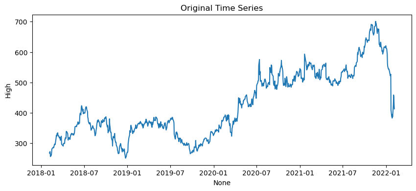

```python
# Create a figure with specific dimensions
plt.figure(figsize=(10, 4))

# Plot the 'High' price over time using Seaborn
sns.lineplot(time_series, x= time_series.index, y = 'High')

# Add a title to the chart
plt.title('Original Time Series')

# Keep x-axis labels horizontal for readability
plt.xticks(rotation = 0)

# Display the plot
plt.show()
```

# 4. Time Series Analysis

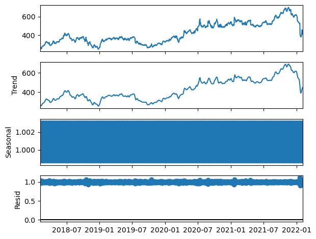

```python
plt.figure(figsize=(15,16))

# Decompose the time series into trend, seasonal, and residual components
# Using 'multiplicative' since the amplitude of seasonality changes with the level of the series
result = seasonal_decompose(time_series, model='multiplicative',extrapolate_trend='freq')

# Plot the decomposition results
result.plot()
plt.show()
```

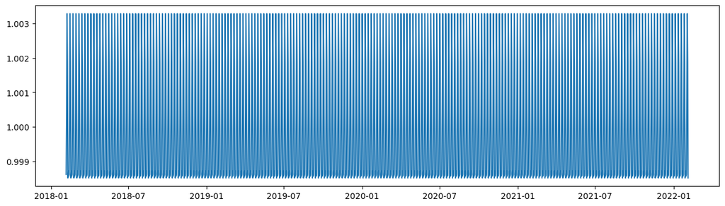

```python
plt.figure(figsize=(15,4))

# Plot only the seasonal component from the decomposition result
plt.plot(result.seasonal)
```

- The Trend component shows a clear long-term upward movement in Netflix’s stock price from 2018 to late 2021, followed by a noticeable decline in early 2022.
- The Seasonal component remains almost constant around 1.0, suggesting no strong seasonal pattern in daily stock prices.
- The Residual (noise) component fluctuates slightly around 1.0, indicating that most variation is explained by the trend rather than seasonality.

# 5. Train–Test Split

```python
# Calculate the size of the training dataset (85% of total data)
train_size = int(0.85*time_series.size)

# Split the time series into training and testing sets
train = time_series.iloc[:train_size] # First 85% for model training
test = time_series.iloc[train_size:]  # Remaining 15% for model testing
```

# 6. Time Series using SARIMA

```python
# Define a function to perform the Augmented Dickey-Fuller test

def adf_test(series):
    # Run the ADF test on the given series
    result = adfuller(series)

    # Print the ADF statistic and p-value
    print('ADF Statistic:', result[0])
    print('p-value:', result[1])

    # Interpret the p-value to determine stationarity
    if (result[1]<0.05):
        print('Data is stationary')
    else:
        print('Data is not stationary')
```

## Identify p, d, q

- Apply the ADF test to check if the series is stationary
- Visualize the original time series to observe overall trends

```
ADF Statistic: -1.8493324619366518
p-value: 0.3562588724397656
Data is not stationary
```

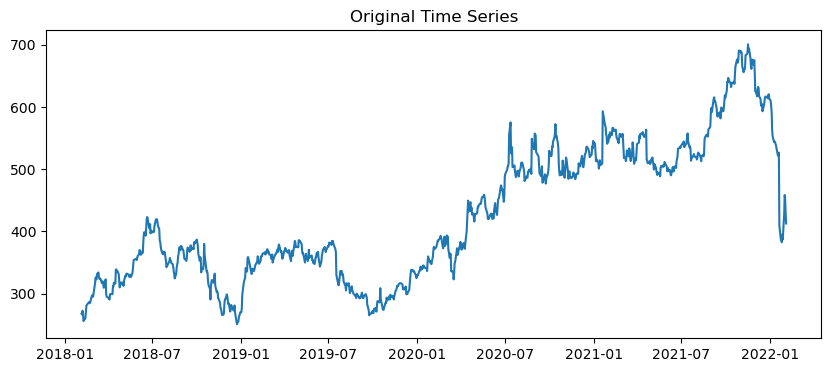

```python
# Perform the Augmented Dickey-Fuller test on the time series
adf_test(time_series)

# Plot the original time series to visualize its pattern over time
plt.figure(figsize=(10, 4))
plt.plot(time_series)
plt.title('Original Time Series')
plt.show()
```

Because data is not stationary

- Apply first differencing to make the series stationary
- Re-run the ADF test to confirm stationarity
- Visualize the differenced series

```
ADF Statistic: -34.388587606401266
p-value: 0.0
Data is stationary
```

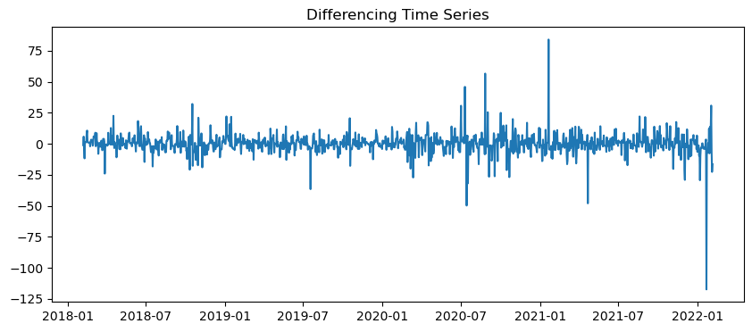

```python
# Apply first differencing to remove trend and make the data stationary
diff_series = time_series.diff(1).dropna()

# Check stationarity again after differencing
adf_test(diff_series)

# Plot the differenced time series to visualize changes
plt.figure(figsize=(10, 4))
plt.plot(diff_series)
plt.title('Differencing Time Series')
plt.show()
```

After applying first differencing, the time series fluctuates around zero without a clear upward or downward trend — indicating stationarity. Therefore, the differencing order (d) for ARIMA modeling is: d = 1

- Plot ACF and PACF to identify ARIMA model parameters
- Use them to estimate values of p (AR) and q (MA)

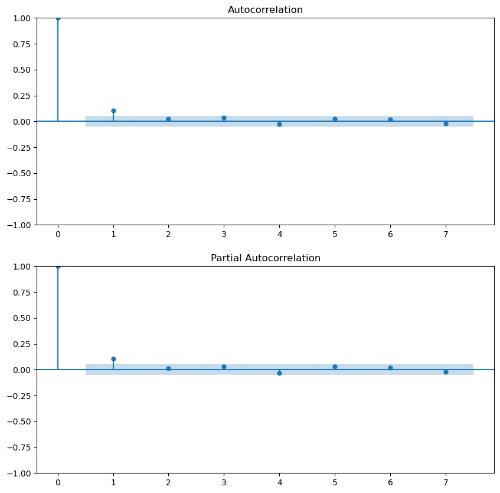

```python
# Plot ACF (Autocorrelation Function) and PACF (Partial Autocorrelation Function)
fig, ax = plt.subplots(2, 1, figsize=(10, 10))

# ACF helps identify the MA (q) component
plot_acf(diff_series, ax=ax[0], lags = 7, alpha= 0.05)

# PACF helps identify the AR (p) component
plot_pacf(diff_series, ax=ax[1], lags= 7, alpha =0.05)

# Display both plots
plt.show()
```

## Identify P, D, Q, m

Xét mùa vụ m = 7

```
ADF Statistic: -6.780131544712368
p-value: 2.5117379350432875e-09
Data is stationary
```

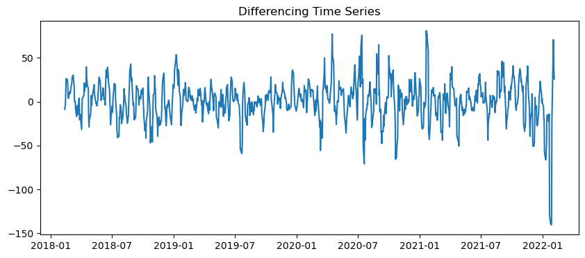

```python
# Apply seasonal differencing with a 7-day lag to handle weekly seasonality
seasonal_diff_series = time_series.diff(7).dropna()

# Test stationarity after seasonal differencing
adf_test(seasonal_diff_series)

# Plot the differenced time series
plt.figure(figsize=(10, 4))
plt.plot(seasonal_diff_series)
plt.title('Differencing Time Series')
plt.show()
```

After applying seasonal differencing with m = 7, the ADF test shows a very low p-value, confirming that the data is now stationary.

The seasonal component has been effectively removed. Therefore, for the SARIMA model, the seasonal differencing order is: D = 1, m = 7

After confirming that the series is stationary (both trend and seasonality removed), the next step is to determine the appropriate ARIMA/SARIMA parameters. By plotting the ACF (Autocorrelation Function) and PACF (Partial Autocorrelation Function), we can identify the suitable orders of:

p → number of autoregressive (AR) terms (from PACF)

q → number of moving average (MA) terms (from ACF)

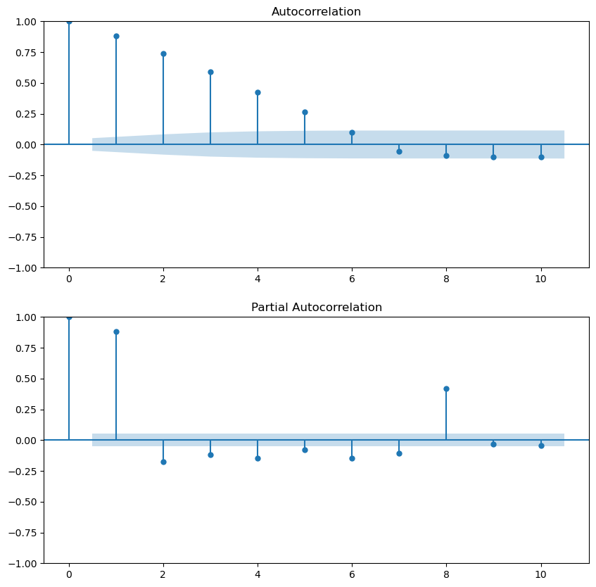

```python
# Plot ACF and PACF to identify ARIMA parameters (p and q)
fig, ax = plt.subplots(2, 1, figsize=(10, 10))

# ACF plot: shows correlation between current value and past values
# → helps estimate q (order of MA term)
plot_acf(seasonal_diff_series, ax=ax[0], lags = 10, alpha= 0.05)


# PACF plot: shows correlation between current value and lag after removing intermediate effects
# → helps estimate p (order of AR term)
plot_pacf(seasonal_diff_series, ax=ax[1], lags= 10, alpha =0.05)

# Display both plots for interpretation
plt.show()
```

From the updated ACF and PACF plots:

The ACF gradually decreases and cuts off after lag 6 → suggests MA(6) behavior.

The PACF shows strong spikes at lags 1 and 8 → suggests AR(1) or AR(8) terms.

Based on these plots, we select P = 9 và q = 6

## Apply SARIMA Model

```python
# Define SARIMA model parameters
p, d, q = 2, 1, 2 # Non-seasonal ARIMA terms
P, D, Q, m = 9,1,6,7  # Seasonal SARIMA terms

# Build the SARIMA model using the training data
model = sm.tsa.SARIMAX(train, order=(p, d, q),seasonal_order = (P, D, Q,m))

# Fit the model to estimate parameters
model_fit = model.fit()

# Display model summary with AIC, coefficients, and diagnostics
print(model_fit.summary())
```

```
 This problem is unconstrained.
```

[output not shown]

[output cut: 34 more lines]

```
ma.S.L14       0.5186      0.242      2.140      0.032       0.044       0.994
ma.S.L21      -0.1343      0.290     -0.463      0.643      -0.703       0.434
ma.S.L28      -0.6890      0.266     -2.588      0.010      -1.211      -0.167
ma.S.L35      -0.4197      0.202     -2.074      0.038      -0.816      -0.023
ma.S.L42      -0.8083      0.129     -6.280      0.000      -1.061      -0.556
sigma2        48.0370      6.171      7.784      0.000      35.941      60.133
===================================================================================
Ljung-Box (L1) (Q):                   0.01   Jarque-Bera (JB):             31075.29
Prob(Q):                              0.94   Prob(JB):                         0.00
Heteroskedasticity (H):               2.62   Skew:                             1.21
Prob(H) (two-sided):                  0.00   Kurtosis:                        27.47
===================================================================================

Warnings:
[1] Covariance matrix calculated using the outer product of gradients (complex-step).
```

Generate forecasts for the test period using the fitted SARIMA model

```python
# Generate forecasts for the same length as the test dataset
forecast = pd.DataFrame(model_fit.forecast(steps = int(test.size)))
forecast.head()
```

|  | predicted_mean |
| --- | --- |
| 2021-06-30 | 538.463601 |
| 2021-07-01 | 537.322837 |
| 2021-07-02 | 536.692563 |
| 2021-07-03 | 537.323966 |
| 2021-07-04 | 537.976252 |

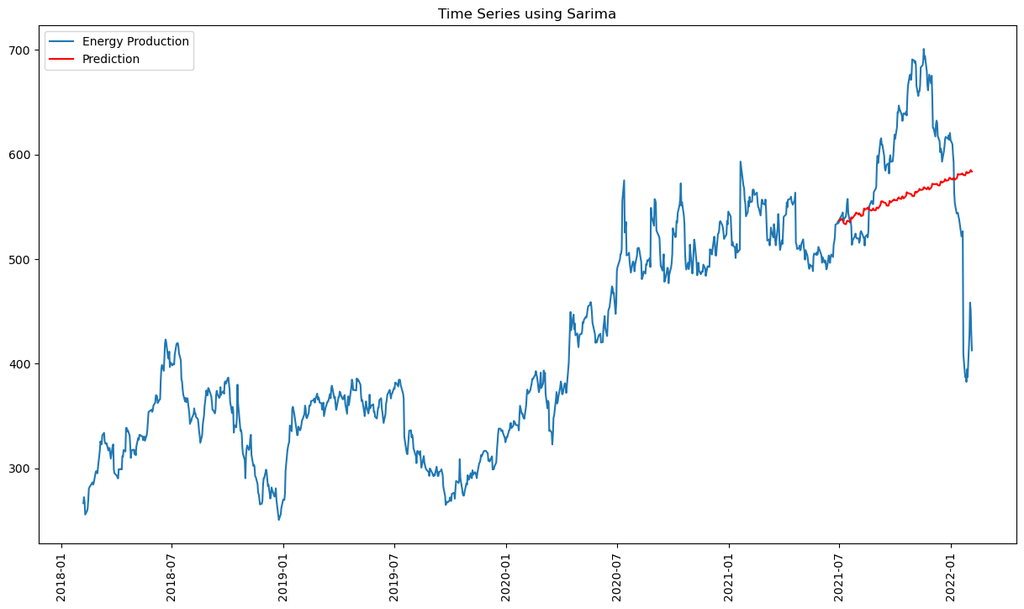

```python
plt.figure(figsize=(15,8))

# Plot the original time series (actual data)
plt.plot(time_series.iloc[1:], label='Energy Production')

# Plot the SARIMA model predictions
plt.plot(forecast.iloc[1:], label='Prediction', color='red')

# Rotate x-axis labels for readability
plt.xticks(rotation='vertical')

# Add title and legend for clarity
plt.title('Time Series using Sarima')
plt.legend()
plt.show()
```

Evaluate SARIMA model performance using MAE and MSE

```python
from sklearn import metrics

# Calculate MAE (Mean Absolute Error) and MSE (Mean Squared Error)
mae_sarima = metrics.mean_absolute_error(test, forecast)
mse_sarima = metrics.mean_squared_error(test, forecast)

# Initialize lists to store model performance
mae_models = []
model_names = []

# Append SARIMA results for comparison
mae_models.append(mae_sarima)
model_names.append('Sarima')

# Print evaluation metrics
print('MAE', mae_sarima)
print('MSE', mse_sarima)
```

```
MAE 59.23945540888018
MSE 5757.2400997244085
```

The SARIMA model gives a MAE ≈ 59.2, which is relatively high. This indicates that the model’s forecasts still have notable deviation from actual values.

Although SARIMA captures general patterns, it doesn’t predict accurately enough for this dataset. It’s advisable to test other models such as Auto ARIMA and LSTM to compare performance and improve forecast accuracy.

# 7. Time Series using Auto ARIMA

Use Auto ARIMA to automatically find the best SARIMA parameters

It tests multiple combinations of (p, d, q) and (P, D, Q, m)

Selects the model with the lowest AIC (Akaike Information Criterion)

```python
# Automatically find the optimal SARIMA parameters using Auto ARIMA
auto_model = auto_arima(train,
                        max_p = 5, max_q = 9, # Maximum range for non-seasonal AR (p) and MA (q)
                        start_P = 0, start_Q = 0, # Starting values for seasonal AR (P) and MA (Q)
                        max_P = 5, max_Q = 5, # Maximum range for seasonal AR and MA
                        m = 7, # Seasonality period (weekly data)
                        d = 1, D = 1,  # Differencing orders for trend and seasonality
                        seasonal = True, # Enable seasonal component
                        trace = True,  # Print model testing progress
                        stepwise = True,  # Use stepwise search for faster convergence
                        error_action = 'ignore',   # Ignore non-converging models
                        suppress_warnings = True) # Suppress warning messages
```

```
Performing stepwise search to minimize aic
 ARIMA(2,1,2)(0,1,0)[7]             : AIC=inf, Time=0.99 sec
 ARIMA(0,1,0)(0,1,0)[7]             : AIC=9217.002, Time=0.02 sec
 ARIMA(1,1,0)(1,1,0)[7]             : AIC=8873.031, Time=0.15 sec
 ARIMA(0,1,1)(0,1,1)[7]             : AIC=inf, Time=1.58 sec
 ARIMA(1,1,0)(0,1,0)[7]             : AIC=9211.021, Time=0.06 sec
 ARIMA(1,1,0)(2,1,0)[7]             : AIC=8689.679, Time=0.50 sec
 ARIMA(1,1,0)(3,1,0)[7]             : AIC=8586.320, Time=1.33 sec
 ARIMA(1,1,0)(4,1,0)[7]             : AIC=8535.173, Time=1.13 sec
 ARIMA(1,1,0)(5,1,0)[7]             : AIC=8504.430, Time=2.57 sec
 ARIMA(1,1,0)(5,1,1)[7]             : AIC=inf, Time=22.89 sec
 ARIMA(1,1,0)(4,1,1)[7]             : AIC=inf, Time=13.99 sec
 ARIMA(0,1,0)(5,1,0)[7]             : AIC=8515.558, Time=1.68 sec
 ARIMA(2,1,0)(5,1,0)[7]             : AIC=8506.272, Time=2.57 sec
 ARIMA(1,1,1)(5,1,0)[7]             : AIC=8506.244, Time=3.58 sec
 ARIMA(0,1,1)(5,1,0)[7]             : AIC=8504.807, Time=2.38 sec
 ARIMA(2,1,1)(5,1,0)[7]             : AIC=inf, Time=28.53 sec
 ARIMA(1,1,0)(5,1,0)[7] intercept   : AIC=8506.430, Time=13.07 sec

Best model:  ARIMA(1,1,0)(5,1,0)[7]
Total fit time: 97.079 seconds
```

```python
# Fit the Auto ARIMA model using the training data
auto_model.fit(train)
```

```
 ARIMA(1,1,0)(5,1,0)[7]
```

Dự đoán cho tập test

```python
# Predict future values for the same length as the test dataset
auto_arima_predict = auto_model.predict(n_periods=len(test))
```

```python
# Convert predictions into a DataFrame with the same index as the test set
auto_arima_predict = pd.DataFrame(auto_arima_predict,index = test.index,columns=['Prediction'])
auto_arima_predict.head()
```

|  | Prediction |
| --- | --- |
| 2021-06-30 | 533.777805 |
| 2021-07-01 | 534.794049 |
| 2021-07-02 | 539.611270 |
| 2021-07-03 | 539.626836 |
| 2021-07-04 | 539.642353 |

Evaluate the Auto ARIMA model performance using MAE and MSE

```python
# Calculate Mean Absolute Error (MAE) and Mean Squared Error (MSE)
mae_autoarima = metrics.mean_absolute_error(test, auto_arima_predict)
mse_autoarima = metrics.mean_squared_error(test, auto_arima_predict)

# Add Auto ARIMA results to comparison lists
mae_models.append(mae_autoarima)
model_names.append('Auto Arima')

# Print evaluation metrics for Auto ARIMA
print('MAE', mae_autoarima)
print('MSE', mse_autoarima)
```

```
MAE 86.59250789501169
MSE 18580.653649658565
```

The Auto ARIMA model achieved a MAE ≈ 86, which is quite high. This suggests the model’s predictions deviate notably from actual stock prices.

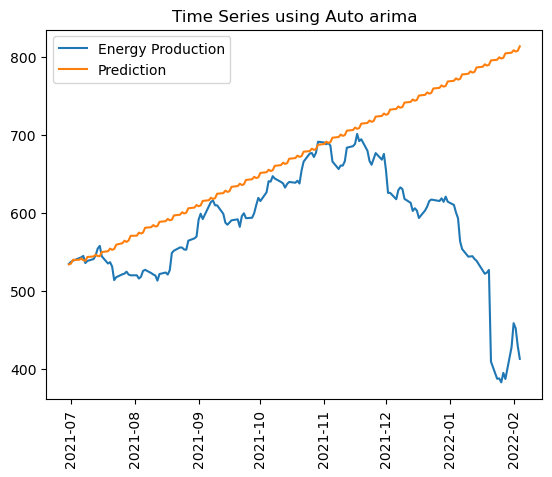

```python
# Plot actual vs predicted values from the Auto ARIMA model
plt.plot(test, label='Energy Production')
# Plot predicted values
plt.plot(auto_arima_predict, label='Prediction')
# Rotate x-axis labels for clarity
plt.xticks(rotation='vertical')
# Add title and legend
plt.title('Time Series using Auto arima')
plt.legend()

plt.show()
```

Display a full comparison between actual data and Auto ARIMA predictions

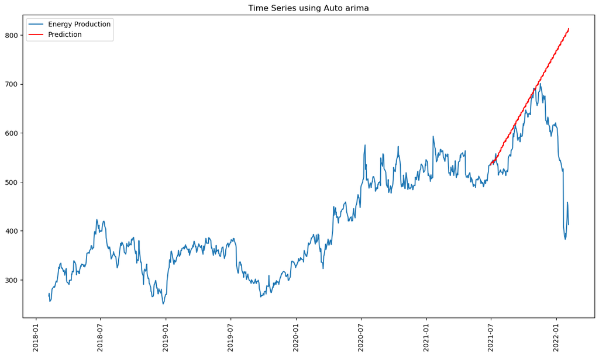

```python
plt.figure(figsize=(15,8))

# Plot the original time series (actual values)
plt.plot(time_series.iloc[1:], label='Energy Production')
# Plot Auto ARIMA model predictions in red
plt.plot(auto_arima_predict.iloc[1:], label='Prediction', color='red')
# Rotate x-axis labels for readability
plt.xticks(rotation='vertical')
# Add chart title and legend
plt.title('Time Series using Auto arima')
plt.legend()

plt.show()
```

From the plot, Auto ARIMA successfully captured the upward trend, but it failed to adapt to the sharp downward movement in stock prices.

This indicates the model performs well for stable or rising trends, but struggles with sudden market drops, implying a need for more flexible models such as LSTM for improved forecasting accuracy

Create a comparison table of model performance

```python
mae_comparison = pd.DataFrame(
    {
        'model_name': model_names,
        'mae': mae_models
    }
)
mae_comparison
```

|  | model_name | mae |
| --- | --- | --- |
| 0 | Sarima | 59.239455 |
| 1 | Auto Arima | 86.592508 |

For this dataset, the SARIMA model performs better, it produces lower forecast error (MAE), meaning its predictions are more accurate than those of the Auto ARIMA model.

# 8. Time Series using Machine Learning (Random Forest & XGBoost)

### Scaling & Data Splitting

```python
from sklearn.preprocessing import MinMaxScaler

# Initialize the MinMaxScaler to scale data between 0 and 1
scaler = MinMaxScaler()
# Fit the scaler to the time series and transform it
time_series = scaler.fit_transform(time_series)
```

Create functions to define X, y for the dataset

```python
# Create sequences of time steps for supervised learning (LSTM input)
def create_dataset(data,time_steps):
    X,y = [], []
    for i in range(len(data)-time_steps):
        # Use 'time_steps' previous values as features
        X.append(data[i:(i+time_steps)])
        # The next value after the sequence is the prediction target
        y.append(data[i+time_steps])
    return np.array(X), np.array(y)

# Split the dataset into training and testing sets
def train_test_split_series(X,y,train_size):
    train_size = int(len(X)*train_size)
    X_train, X_test = X[:train_size], X[train_size:]
    y_train, y_test = y[:train_size], y[train_size:]

    return X_train, X_test, y_train, y_test
```

```python
# Create input (X) and output (y) datasets using 7-day sequences
X,y = create_dataset(np.array(time_series),7)
```

```python
X.shape
```

```
(1454, 7, 1)
```

```python
# Split the data: 85% for training, 15% for testing
X_train, X_test, y_train, y_test = train_test_split_series(X,y,0.85)
```

```python
# check shapes of the resulting datasets
print('X_train shape', X_train.shape)
print('X_test shape', X_test.shape)
print('y_train shape', y_train.shape)
print('y_test shape', y_test.shape)
```

```
X_train shape (1235, 7, 1)
X_test shape (219, 7, 1)
y_train shape (1235, 1)
y_test shape (219, 1)
```

Reshape input data to prepare for model training

```python
# Reshape training and testing input sets into 2D arrays
# (samples, features) format for model compatibility
X_train_reshaped = X_train.reshape(X_train.shape[0], -1)
X_test_reshaped = X_test.reshape(X_test.shape[0], -1)

# Print new shapes to confirm successful reshaping
print("X_train_reshaped shape:", X_train_reshaped.shape)
print("X_test_reshaped shape:", X_test_reshaped.shape)

# Flatten the output (target) arrays
y_train_flattened = y_train.reshape(-1)
y_test_flattened = y_test.reshape(-1)

# Print flattened output shapes
print(y_train_flattened.shape, y_test_flattened.shape)
```

```
X_train_reshaped shape: (1235, 7)
X_test_reshaped shape: (219, 7)
(1235,) (219,)
```

### Random Forest

- Train a Random Forest Regressor to predict future values
- se all CPU cores `(n_jobs=-1)` for faster training

```python
from sklearn.ensemble import RandomForestRegressor

# Initialize the Random Forest model using all available processors
model = RandomForestRegressor(n_jobs=-1)

# Train the model with the reshaped training data
model.fit(X_train_reshaped, y_train)
```

```
RandomForestRegressor(n_jobs=-1)
```

Predict target values using the trained Random Forest model

```python
# Generate predictions from the trained Random Forest model
y_pred_forest = model.predict(X_test_reshaped)
```

Evaluate model performance using MSE and MAE before inverse scaling

```python
from sklearn.metrics import mean_squared_error, mean_absolute_error, r2_score


# Calculate MSE (Mean Squared Error) and MAE (Mean Absolute Error)
mse_forest = mean_squared_error(y_test_flattened, y_pred_forest)
mae_forest = mean_absolute_error(y_test_flattened, y_pred_forest)


# Display evaluation metrics before inverse scaling
print('mse before inverse:', mse_forest)
print('mae before inverse:', mae_forest)
```

```
mse before inverse: 0.016515622125066215
mae before inverse: 0.09346430270273048
```

```python
from sklearn.metrics import mean_squared_error, mean_absolute_error, r2_score


# Inverse transform predicted and actual values to original scale
y_pred_actual = scaler.inverse_transform(y_pred_forest.reshape(-1,1))
y_test_actual = scaler.inverse_transform(y_test.reshape(-1,1))


# Recalculate error metrics after inverse scaling
mse_forest = mean_squared_error(y_test_actual, y_pred_actual)
mae_forest = mean_absolute_error(y_test_actual, y_pred_actual)


# Store Random Forest results for model comparison
mae_models.append(mae_forest)
model_names.append('Random Forest')


# Display final evaluation metrics
print('mse after inverse:', mse_forest)
print('mae after inverse:', mae_forest)
```

```
mse after inverse: 3349.4691699020987
mae after inverse: 42.09071407914766
```

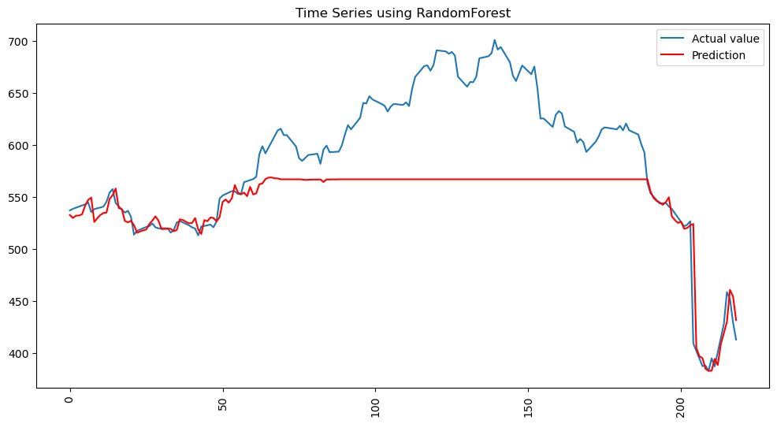

```python
plt.figure(figsize=(12,6))
# Plot actual (true) values
plt.plot(y_test_actual, label = 'Actual value')
# Plot predicted values in red
plt.plot(y_pred_actual, label = 'Prediction', color = 'red')
# Rotate x-axis labels for readability
plt.xticks(rotation = 'vertical')
# Add title and legend
plt.title('Time Series using RandomForest')
plt.legend()
plt.show()
```

```python
mae_comparison = pd.DataFrame(
    {
        'model_name': model_names,
        'mae': mae_models
    }
)
mae_comparison
```

|  | model_name | mae |
| --- | --- | --- |
| 0 | Sarima | 59.239455 |
| 1 | Auto Arima | 86.592508 |
| 2 | Random Forest | 42.090714 |

The Random Forest model achieved the lowest MAE, meaning it performs better numerically than SARIMA and Auto ARIMA.

### XGBoost

- Train an XGBoost Regressor for time series prediction
- XGBoost can model nonlinear relationships and often outperforms Random Forest in structured data

```python
import xgboost as xgb
```

```python
# Initialize the XGBoost Regressor model
xgb_model = xgb.XGBRegressor()

# Train the model using the reshaped training data
xgb_model.fit(X_train_reshaped, y_train)
```

```
XGBRegressor(base_score=None, booster=None, callbacks=None,
             colsample_bylevel=None, colsample_bynode=None,
             colsample_bytree=None, device=None, early_stopping_rounds=None,
             enable_categorical=False, eval_metric=None, feature_types=None,
             gamma=None, grow_policy=None, importance_type=None,
             interaction_constraints=None, learning_rate=None, max_bin=None,
             max_cat_threshold=None, max_cat_to_onehot=None,
             max_delta_step=None, max_depth=None, max_leaves=None,
             min_child_weight=None, missing=nan, monotone_constraints=None,
             multi_strategy=None, n_estimators=None, n_jobs=None,
             num_parallel_tree=None, random_state=None, ...)
```

```python
# Predict future values using the trained XGBoost model
y_pred = xgb_model.predict(X_test_reshaped)
```

```python
from sklearn.metrics import mean_squared_error, mean_absolute_error, r2_score

# Compute evaluation metrics before inverse transformation
mse_xgb = mean_squared_error(y_test_flattened, y_pred)
mae_xgb = mean_absolute_error(y_test_flattened, y_pred)


# Display model performance results
print('mse before inverse:', mse_xgb)
print('mae before inverse:', mae_xgb)
```

```
mse before inverse: 0.020620782750170815
mae before inverse: 0.10643160651458256
```

```python
from sklearn.metrics import mean_squared_error, mean_absolute_error, r2_score


# Inverse transform predictions and true values to the original scale
y_pred_actual = scaler.inverse_transform(y_pred.reshape(-1,1))
y_test_actual = scaler.inverse_transform(y_test.reshape(-1,1))


# Compute error metrics after scaling back
mse_xgb = mean_squared_error(y_test_actual, y_pred_actual)
mae_xgb = mean_absolute_error(y_test_actual, y_pred_actual)


# Store XGBoost results for later comparison
mae_models.append(mae_xgb)
model_names.append('XGBoost')

print('mse after inverse:', mse_xgb)
print('mae after inverse:', mae_xgb)
```

```
mse after inverse: 4182.0198027323695
mae after inverse: 47.930402302502486
```

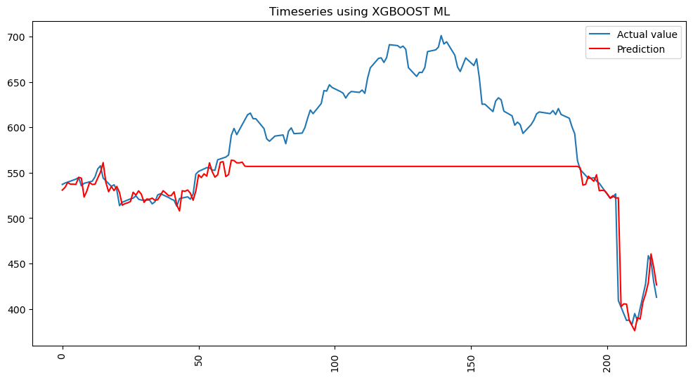

```python
# Plot actual vs predicted values
plt.figure(figsize=(12,6))
plt.plot(y_test_actual, label = 'Actual value')
plt.plot(y_pred_actual, label = 'Prediction', color = 'red')
plt.xticks(rotation = 'vertical')
plt.title('Timeseries using XGBOOST ML')
plt.legend()
plt.show()
```

```python
mae_comparison = pd.DataFrame(
    {
        'model_name': model_names,
        'mae': mae_models
    }
)
mae_comparison
```

|  | model_name | mae |
| --- | --- | --- |
| 0 | Sarima | 59.239455 |
| 1 | Auto Arima | 86.592508 |
| 2 | Random Forest | 42.090714 |
| 3 | XGBoost | 47.930402 |

The XGBoost model performs similarly to Random Forest, but does not show significant improvement. However, both tree-based models outperform SARIMA and Auto ARIMA, achieving lower forecast errors overall, indicating that machine learning models capture nonlinear patterns in the time series more effectively.